# IODS course project

# Dimensionality reduction techniques - week 5

## Task 1

```r
setwd("D:/New folder/OneDrive for Business 1/Git/IODS/IODS-project/data")
human <- read.table(file = "human.txt",
                    header = TRUE,
                    dec = ".")
```

```r
# Libraries
library(GGally)
library(corrplot)
library(FactoMineR)
library(dplyr)
library(tidyr)
```

```r
# Overview of data
summary(human)
```

```
##     sec.edu         lab.force       expec.birth      expec.edu
##  Min.   :0.1717   Min.   :0.1857   Min.   :49.00   Min.   : 5.40
##  1st Qu.:0.7264   1st Qu.:0.5984   1st Qu.:66.30   1st Qu.:11.25
##  Median :0.9375   Median :0.7535   Median :74.20   Median :13.50
##  Mean   :0.8529   Mean   :0.7074   Mean   :71.65   Mean   :13.18
##  3rd Qu.:0.9968   3rd Qu.:0.8535   3rd Qu.:77.25   3rd Qu.:15.20
##  Max.   :1.4967   Max.   :1.0380   Max.   :83.50   Max.   :20.20
##       GNI           mort.ratio       adol.birth       repres.par
##  Min.   :   581   Min.   :   1.0   Min.   :  0.60   Min.   : 0.00
##  1st Qu.:  4198   1st Qu.:  11.5   1st Qu.: 12.65   1st Qu.:12.40
##  Median : 12040   Median :  49.0   Median : 33.60   Median :19.30
##  Mean   : 17628   Mean   : 149.1   Mean   : 47.16   Mean   :20.91
##  3rd Qu.: 24512   3rd Qu.: 190.0   3rd Qu.: 71.95   3rd Qu.:27.95
##  Max.   :123124   Max.   :1100.0   Max.   :204.80   Max.   :57.50
```

```r
str(human)
```

```
## 'data.frame':    155 obs. of  8 variables:
##  $ sec.edu    : num  1.007 0.997 0.983 0.989 0.969 ...
##  $ lab.force  : num  0.891 0.819 0.825 0.884 0.829 ...
##  $ expec.birth: num  81.6 82.4 83 80.2 81.6 80.9 80.9 79.1 82 81.8 ...
##  $ expec.edu  : num  17.5 20.2 15.8 18.7 17.9 16.5 18.6 16.5 15.9 19.2 ...
##  $ GNI        : int  64992 42261 56431 44025 45435 43919 39568 52947 42155 32689 ...
##  $ mort.ratio : int  4 6 6 5 6 7 9 28 11 8 ...
##  $ adol.birth : num  7.8 12.1 1.9 5.1 6.2 3.8 8.2 31 14.5 25.3 ...
##  $ repres.par : num  39.6 30.5 28.5 38 36.9 36.9 19.9 19.4 28.2 31.4 ...
```

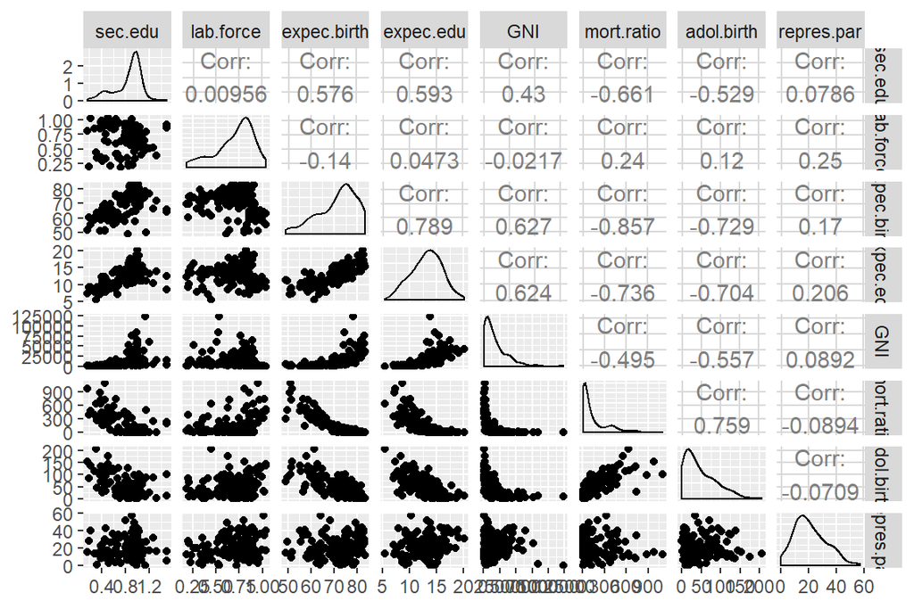

```r
ggpairs(human)
```

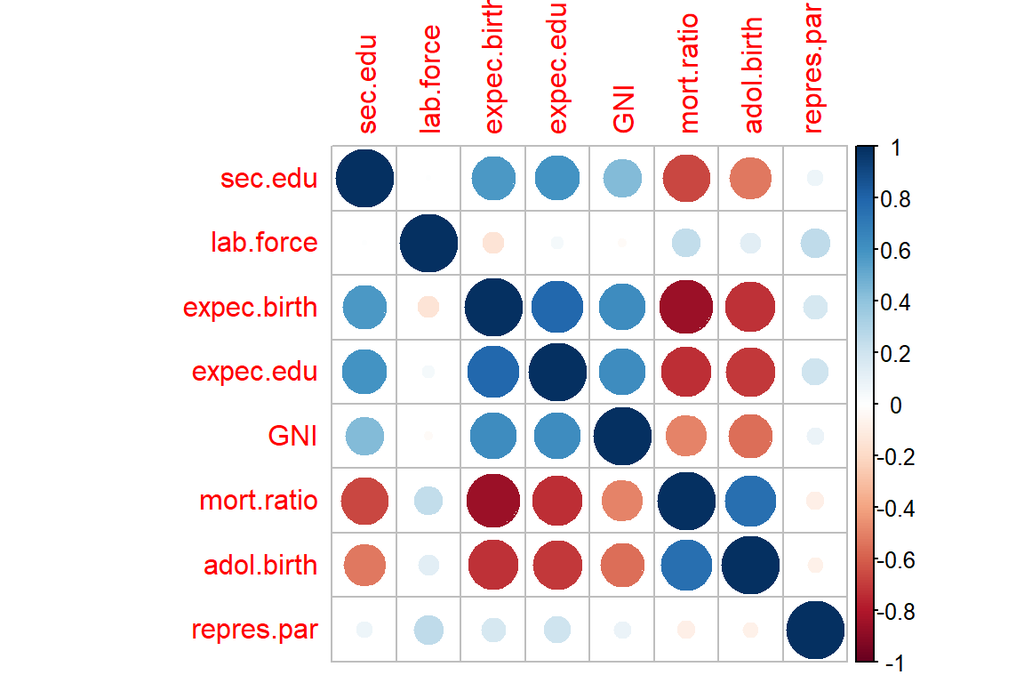

```r
cor(human)%>%corrplot()
```

```r
#Several variables strongly correlate to each other.
```

## Task 2

```r
# PCA on raw data
pca_human_raw <- prcomp(human, scale = FALSE)
pca_human_raw
```

```
## Standard deviations (1, .., p=8):
## [1] 1.854416e+04 1.855219e+02 2.518701e+01 1.145441e+01 3.766241e+00
## [6] 1.565912e+00 1.912052e-01 1.591112e-01
##
## Rotation (n x k) = (8 x 8):
##                       PC1           PC2           PC3           PC4
## sec.edu     -5.607472e-06  0.0006713951 -3.412027e-05 -2.736326e-04
## lab.force    2.331945e-07 -0.0002819357  5.302884e-04 -4.692578e-03
## expec.birth -2.815823e-04  0.0283150248  1.294971e-02 -6.752684e-02
## expec.edu   -9.562910e-05  0.0075529759  1.427664e-02 -3.313505e-02
## GNI         -9.999832e-01 -0.0057723054 -5.156742e-04  4.932889e-05
## mort.ratio   5.655734e-03 -0.9916320120  1.260302e-01 -6.100534e-03
## adol.birth   1.233961e-03 -0.1255502723 -9.918113e-01  5.301595e-03
## repres.par  -5.526460e-05  0.0032317269 -7.398331e-03 -9.971232e-01
##                       PC5           PC6           PC7           PC8
## sec.edu     -0.0022935252  2.180183e-02  6.998623e-01  7.139410e-01
## lab.force    0.0022190154  3.264423e-02  7.132267e-01 -7.001533e-01
## expec.birth  0.9865644425 -1.453515e-01  5.380452e-03  2.281723e-03
## expec.edu    0.1431180282  9.882477e-01 -3.826887e-02  7.776451e-03
## GNI         -0.0001135863 -2.711698e-05 -8.075191e-07 -1.176762e-06
## mort.ratio   0.0266373214  1.695203e-03  1.355518e-04  8.371934e-04
## adol.birth   0.0188618600  1.273198e-02 -8.641234e-05 -1.707885e-04
## repres.par  -0.0716401914 -2.309896e-02 -2.642548e-03  2.680113e-03
```

Among all variables, GNI had a stronger correlation with PC1. Since the variables weren’t standardized, the magnitude and range of some variables, especially of GNI, was much greater, so the PCA gave more emphasis to GNI.

```r
s <- summary(pca_human_raw)
s
```

```
## Importance of components:
##                              PC1      PC2   PC3   PC4   PC5   PC6    PC7
## Standard deviation     1.854e+04 185.5219 25.19 11.45 3.766 1.566 0.1912
## Proportion of Variance 9.999e-01   0.0001  0.00  0.00 0.000 0.000 0.0000
## Cumulative Proportion  9.999e-01   1.0000  1.00  1.00 1.000 1.000 1.0000
##                           PC8
## Standard deviation     0.1591
## Proportion of Variance 0.0000
## Cumulative Proportion  1.0000
```

PC1 explains 100% of the total variance in the data.

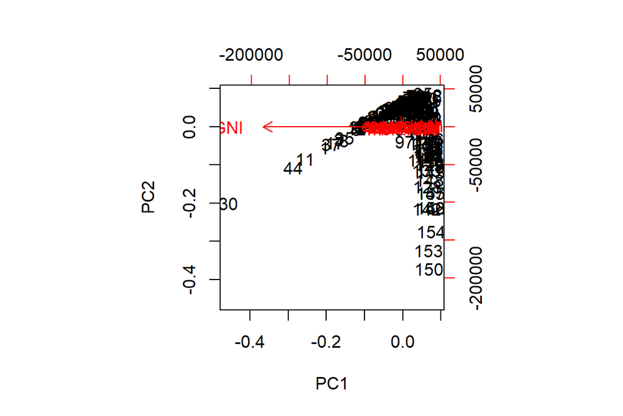

```r
# Draw a biplot of the principal component representation and the original variables
biplot(pca_human_raw)
```

## Task 3

```r
# PCA with standardized data
pca_human_std <- prcomp(human, scale=TRUE)
pca_human_std
```

```
## Standard deviations (1, .., p=8):
## [1] 2.0708380 1.1397204 0.8750485 0.7788630 0.6619563 0.5363061 0.4589994
## [8] 0.3222406
##
## Rotation (n x k) = (8 x 8):
##                     PC1         PC2         PC3         PC4        PC5
## sec.edu     -0.35664370  0.03796058 -0.24223089  0.62678110 -0.5983585
## lab.force    0.05457785  0.72432726 -0.58428770  0.06199424  0.2625067
## expec.birth -0.44372240 -0.02530473  0.10991305 -0.05834819  0.1628935
## expec.edu   -0.42766720  0.13940571 -0.07340270 -0.07020294  0.1659678
## GNI         -0.35048295  0.05060876 -0.20168779 -0.72727675 -0.4950306
## mort.ratio   0.43697098  0.14508727 -0.12522539 -0.25170614 -0.1800657
## adol.birth   0.41126010  0.07708468  0.01968243  0.04986763 -0.4672068
## repres.par  -0.08438558  0.65136866  0.72506309  0.01396293 -0.1523699
##                     PC6         PC7         PC8
## sec.edu      0.17713316  0.05773644  0.16459453
## lab.force   -0.03500707 -0.22729927 -0.07304568
## expec.birth -0.42242796 -0.43406432  0.62737008
## expec.edu   -0.38606919  0.77962966 -0.05415984
## GNI          0.11120305 -0.13711838 -0.16961173
## mort.ratio   0.17370039  0.35380306  0.72193946
## adol.birth  -0.76056557 -0.06897064 -0.14335186
## repres.par   0.13749772  0.00568387 -0.02306476
```

Life expectancy at birth, Expected years of schooling, Proportion of females/males with at least secondary education, and Gross National Income per capita show a strong and negative correlation with PC1, while Maternal mortality ratio and Adolescent birth rate showed a strong positive correlation with PC1. Percetange of female representatives in parliament and Proportion of females/males in the labour force showed a strong positive correlation with PC2.

```r
# Create and print out a summary of pca_human
s <- summary(pca_human_std)
s
```

```
## Importance of components:
##                           PC1    PC2     PC3     PC4     PC5     PC6
## Standard deviation     2.0708 1.1397 0.87505 0.77886 0.66196 0.53631
## Proportion of Variance 0.5361 0.1624 0.09571 0.07583 0.05477 0.03595
## Cumulative Proportion  0.5361 0.6984 0.79413 0.86996 0.92473 0.96069
##                            PC7     PC8
## Standard deviation     0.45900 0.32224
## Proportion of Variance 0.02634 0.01298
## Cumulative Proportion  0.98702 1.00000
```

```r
# Assigning the proportion of variance as percent to each PC
pca_pr <- round(100*s$importance[2, ], digits = 1)
pc_lab<-paste0(names(pca_pr), " (", pca_pr, "%)")
pc_lab
```

```
## [1] "PC1 (53.6%)" "PC2 (16.2%)" "PC3 (9.6%)"  "PC4 (7.6%)"  "PC5 (5.5%)"
## [6] "PC6 (3.6%)"  "PC7 (2.6%)"  "PC8 (1.3%)"
```

The PCA produced two components with eigenvalues (in units of standard deviation) above 1.0, which explained about 70% of the total variance among the eight original variables.

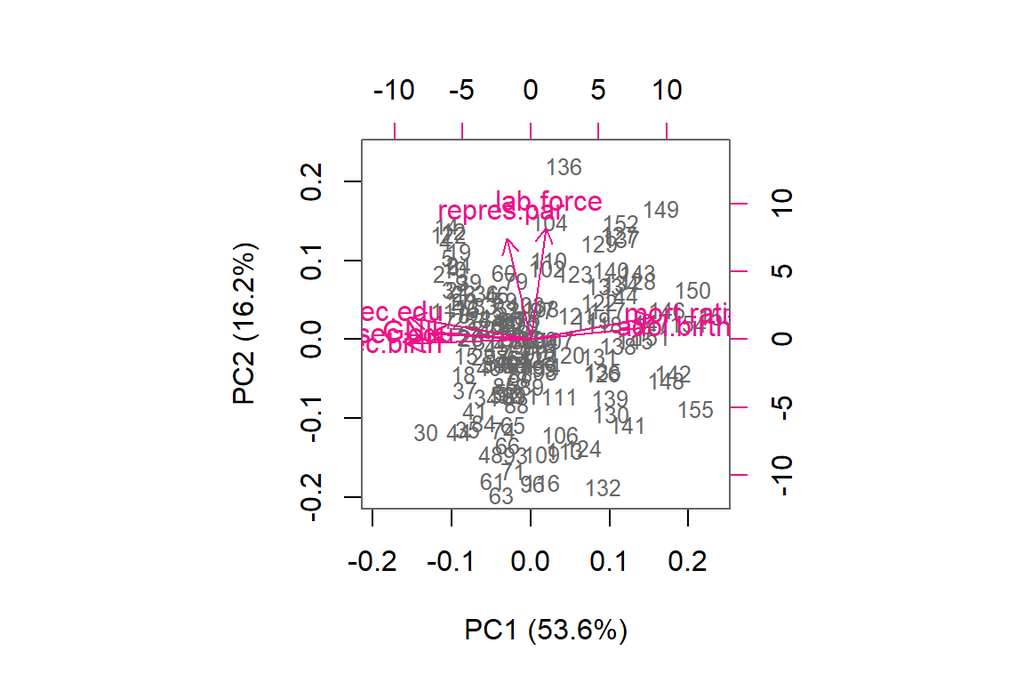

```r
# Draw a biplot of the principal component representation and the original variables
biplot(pca_human_std, cex = c(0.8, 1), col = c("grey40", "deeppink2"), xlab = pc_lab[1], ylab = pc_lab[2])
```

## Task 4

We can see that PC1 and PC1 explained 53.6% and 16.2% of the total variance, respectively. PC1 represents Life expectancy at birth, Expected years of schooling, Proportion of females/males with at least secondary education, and Gross National Income per capita, that strongly correlates with each other, which negatively correlate with Maternal mortality ratio and Adolescent birth rate, that strongly correlate with each other. On the other hand, PC2 represents Percetange of female representatives in parliament and Proportion of females/males in the labour force, which are independent from the other variables in the data set. You can see they are orthogonally positioned on the biplot.

## Task 5

```r
library(FactoMineR)
library(tidyr)
library(dplyr)
library(ggplot2)
```

```r
data(tea)
dim(tea)
```

```
## [1] 300  36
```

```r
str(tea)
```

```
## 'data.frame':    300 obs. of  36 variables:
##  $ breakfast       : Factor w/ 2 levels "breakfast","Not.breakfast": 1 1 2 2 1 2 1 2 1 1 ...
##  $ tea.time        : Factor w/ 2 levels "Not.tea time",..: 1 1 2 1 1 1 2 2 2 1 ...
##  $ evening         : Factor w/ 2 levels "evening","Not.evening": 2 2 1 2 1 2 2 1 2 1 ...
##  $ lunch           : Factor w/ 2 levels "lunch","Not.lunch": 2 2 2 2 2 2 2 2 2 2 ...
##  $ dinner          : Factor w/ 2 levels "dinner","Not.dinner": 2 2 1 1 2 1 2 2 2 2 ...
##  $ always          : Factor w/ 2 levels "always","Not.always": 2 2 2 2 1 2 2 2 2 2 ...
##  $ home            : Factor w/ 2 levels "home","Not.home": 1 1 1 1 1 1 1 1 1 1 ...
##  $ work            : Factor w/ 2 levels "Not.work","work": 1 1 2 1 1 1 1 1 1 1 ...
##  $ tearoom         : Factor w/ 2 levels "Not.tearoom",..: 1 1 1 1 1 1 1 1 1 2 ...
##  $ friends         : Factor w/ 2 levels "friends","Not.friends": 2 2 1 2 2 2 1 2 2 2 ...
##  $ resto           : Factor w/ 2 levels "Not.resto","resto": 1 1 2 1 1 1 1 1 1 1 ...
##  $ pub             : Factor w/ 2 levels "Not.pub","pub": 1 1 1 1 1 1 1 1 1 1 ...
##  $ Tea             : Factor w/ 3 levels "black","Earl Grey",..: 1 1 2 2 2 2 2 1 2 1 ...
##  $ How             : Factor w/ 4 levels "alone","lemon",..: 1 3 1 1 1 1 1 3 3 1 ...
```

[output cut: 22 more lines]

```r
tea_time <-tea%>% dplyr::select(Tea, age, How, where, friends, breakfast)

summary(tea_time)
```

```
##         Tea           age           How                       where
##  black    : 74   Min.   :15.00   alone:195   chain store         :192
##  Earl Grey:193   1st Qu.:23.00   lemon: 33   chain store+tea shop: 78
##  green    : 33   Median :32.00   milk : 63   tea shop            : 30
##                  Mean   :37.05   other:  9
##                  3rd Qu.:48.00
##                  Max.   :90.00
##         friends            breakfast
##  friends    :196   breakfast    :144
##  Not.friends:104   Not.breakfast:156
##
##
##
##
```

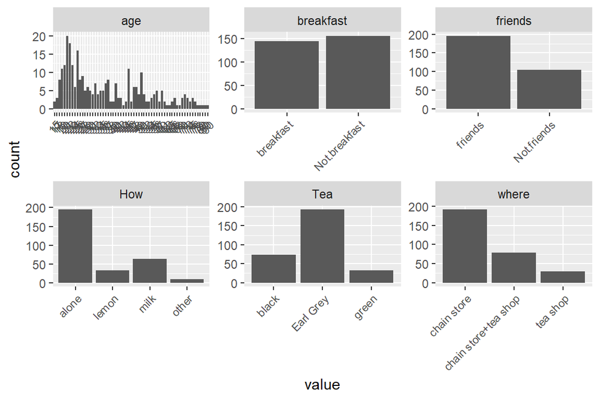

```r
gather(tea_time) %>% ggplot(aes(value)) + facet_wrap("key", scales = "free") +geom_bar()+
  theme(axis.text.x = element_text(angle = 45, hjust = 1, size = 8))
```

```r
mca <- MCA(tea_time, quanti.sup= 2, graph = FALSE)
summary(mca)
```

```
##
## Call:
## MCA(X = tea_time, quanti.sup = 2, graph = FALSE)
##
##
## Eigenvalues
##                        Dim.1   Dim.2   Dim.3   Dim.4   Dim.5   Dim.6
## Variance               0.292   0.266   0.235   0.218   0.180   0.165
## % of var.             16.242  14.803  13.044  12.128   9.975   9.186
## Cumulative % of var.  16.242  31.045  44.088  56.216  66.191  75.377
##                        Dim.7   Dim.8   Dim.9
## Variance               0.156   0.145   0.142
## % of var.              8.693   8.028   7.902
## Cumulative % of var.  84.070  92.098 100.000
##
## Individuals (the 10 first)
##                         Dim.1    ctr   cos2    Dim.2    ctr   cos2
## 1                    | -0.339  0.131  0.081 |  0.824  0.849  0.477 |
## 2                    | -0.084  0.008  0.003 |  1.262  1.994  0.770 |
## 3                    | -0.188  0.040  0.057 | -0.406  0.207  0.266 |
## 4                    | -0.564  0.362  0.356 | -0.007  0.000  0.000 |
## 5                    | -0.362  0.149  0.141 |  0.403  0.203  0.176 |
## 6                    | -0.564  0.362  0.356 | -0.007  0.000  0.000 |
## 7                    |  0.014  0.000  0.000 |  0.003  0.000  0.000 |
## 8                    | -0.286  0.093  0.040 |  0.853  0.909  0.357 |
## 9                    |  0.477  0.260  0.112 |  0.699  0.611  0.241 |
## 10                   |  0.246  0.069  0.032 |  0.681  0.580  0.246 |
##                       Dim.3    ctr   cos2
## 1                     0.207  0.061  0.030 |
## 2                     0.302  0.129  0.044 |
## 3                    -0.495  0.348  0.395 |
## 4                    -0.345  0.169  0.134 |
## 5                    -0.355  0.179  0.136 |
## 6                    -0.345  0.169  0.134 |
## 7                    -0.505  0.362  0.390 |
## 8                     0.311  0.137  0.047 |
## 9                    -0.073  0.008  0.003 |
## 10                    0.395  0.221  0.083 |
##
## Categories (the 10 first)
```

[output cut: 19 more lines]

```
## chain store            0.086   5.057 |  -0.349   6.634   0.216  -8.042 |
## chain store+tea shop   0.008  -1.535 |   0.105   0.243   0.004   1.073 |
## tea shop               0.114  -5.847 |   1.960  32.738   0.427  11.299 |
##
## Categorical variables (eta2)
##                        Dim.1 Dim.2 Dim.3
## Tea                  | 0.273 0.233 0.473 |
## How                  | 0.377 0.439 0.206 |
## where                | 0.503 0.140 0.465 |
## friends              | 0.233 0.241 0.030 |
## breakfast            | 0.074 0.279 0.000 |
##
## Supplementary continuous variable
##                        Dim.1   Dim.2   Dim.3
## age                  | 0.086 | 0.124 | 0.327 |
```

Of all variables,“where” correlated more strongly with dimension 1 (but also with dimension 3), whereas “How” correlated more with dimension 2.“Tea” type correlated with dimension 3. All variables were significant in dim 1. Chain store+tea shop was not significant for dim 2 nor for dim 3. Tea with milk was not significant for dim 3.

```r
dimdesc(mca)
```

```
## $`Dim 1`
## $`Dim 1`$quali
##                   R2      p.value
## where     0.50324995 7.524557e-46
## How       0.37732687 3.019445e-30
## Tea       0.27340440 2.523338e-21
## friends   0.23345584 5.912544e-19
## breakfast 0.07435432 1.631644e-06
##
## $`Dim 1`$category
##                        Estimate      p.value
## chain store+tea shop  0.6096501 1.226985e-46
## friends               0.2744774 5.912544e-19
## other                 0.7852368 1.032975e-12
## lemon                 0.1149361 2.145542e-10
## breakfast             0.1475566 1.631644e-06
## Earl Grey             0.2865841 9.404111e-05
## black                 0.3200220 2.363933e-02
## milk                 -0.2641891 5.285459e-03
## tea shop             -0.3647031 3.913470e-04
## Not.breakfast        -0.1475566 1.631644e-06
## Not.friends          -0.2744774 5.912544e-19
## alone                -0.6359838 1.738080e-21
## chain store          -0.2449470 4.942560e-22
## green                -0.6066061 2.168456e-22
##
##
## $`Dim 2`
## $`Dim 2`$quanti
##     correlation    p.value
## age   0.1240196 0.03176052
##
## $`Dim 2`$quali
##                  R2      p.value
## How       0.4391124 6.243692e-37
## breakfast 0.2792945 5.542412e-23
## friends   0.2410491 1.320700e-19
## Tea       0.2332503 7.431185e-18
## where     0.1395386 2.030530e-10
##
```

[output cut: 26 more lines]

```
## How     0.20575294 9.869805e-15
## friends 0.02992583 2.642919e-03
##
## $`Dim 3`$category
##                Estimate      p.value
## tea shop     0.67270547 6.462175e-38
## black        0.18432316 2.573512e-19
## green        0.29135270 1.409740e-11
## other        0.55976812 5.224949e-08
## lemon        0.12601180 1.086269e-07
## Not.friends  0.08806502 2.642919e-03
## friends     -0.08806502 2.642919e-03
## alone       -0.39818668 5.000153e-08
## chain store -0.44621500 1.655193e-17
## Earl Grey   -0.47567587 6.638625e-43
```

Age is significantly correlated with dim 2 (p<0.05) and dim 3 (p<0.001).

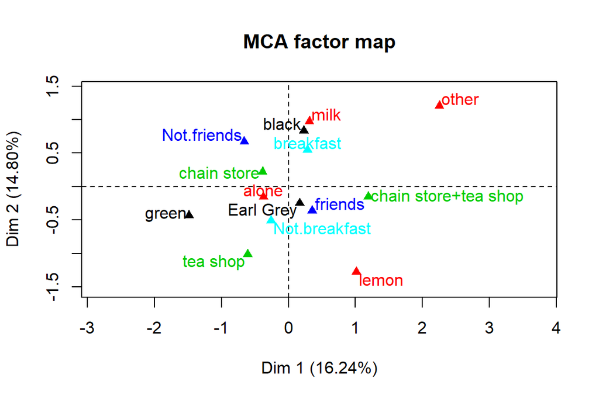

```r
plot(mca, invisible=c("ind"),habillage = "quali")
```

# Analysis of longitudinal data - week 6

## Analysis of RATS data

- According to chapter 8 from MABS

```r
setwd("D:/New folder/OneDrive for Business 1/Git/IODS/IODS-project/data")
RATSL <- read.table(file = "RATSL.txt",
                           header = TRUE,
                           dec = ".")
RATSL$ID <- factor(RATSL$ID)
RATSL$Group <- factor(RATSL$Group)
str(RATSL)
```

```
## 'data.frame':    176 obs. of  5 variables:
##  $ ID    : Factor w/ 16 levels "1","2","3","4",..: 1 2 3 4 5 6 7 8 9 10 ...
##  $ Group : Factor w/ 3 levels "1","2","3": 1 1 1 1 1 1 1 1 2 2 ...
##  $ WD    : Factor w/ 11 levels "WD1","WD15","WD22",..: 1 1 1 1 1 1 1 1 1 1 ...
##  $ Weight: int  240 225 245 260 255 260 275 245 410 405 ...
##  $ Time  : int  1 1 1 1 1 1 1 1 1 1 ...
```

### Libraries

```r
library(dplyr)
library(ggplot2)
library(lme4)
```

### Data exploration

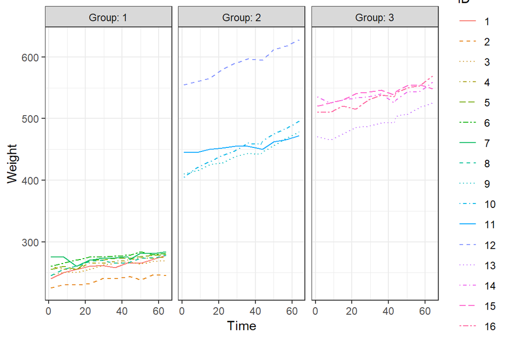

```r
ggplot(RATSL, aes(x = Time, y = Weight, linetype = ID)) +
  geom_line() +
  scale_linetype_manual(values = rep(1:10, times=4)) +
  facet_grid(. ~ Group, labeller = label_both) +
  theme_bw() +geom_line(aes(color=ID))+
  scale_y_continuous(limits = c(min(RATSL$Weight), max(RATSL$Weight)))
```

This graph shows the individual weight of subjects by treatment group. The weight seems to generally increase with time for individuals in every group treatment. One individual from each group seems to either have higher or lower weight compared to individuals of the same group. From the graph You can notice that their initial weight was already very different compared to other individuals. This shows that individuals’ starting weight should be taken into account when quantifying the treatment effects. There are more individuals in group 1, and they appear to have the lowest weight.

Lets see if we can visualize the variability better with standardized data.

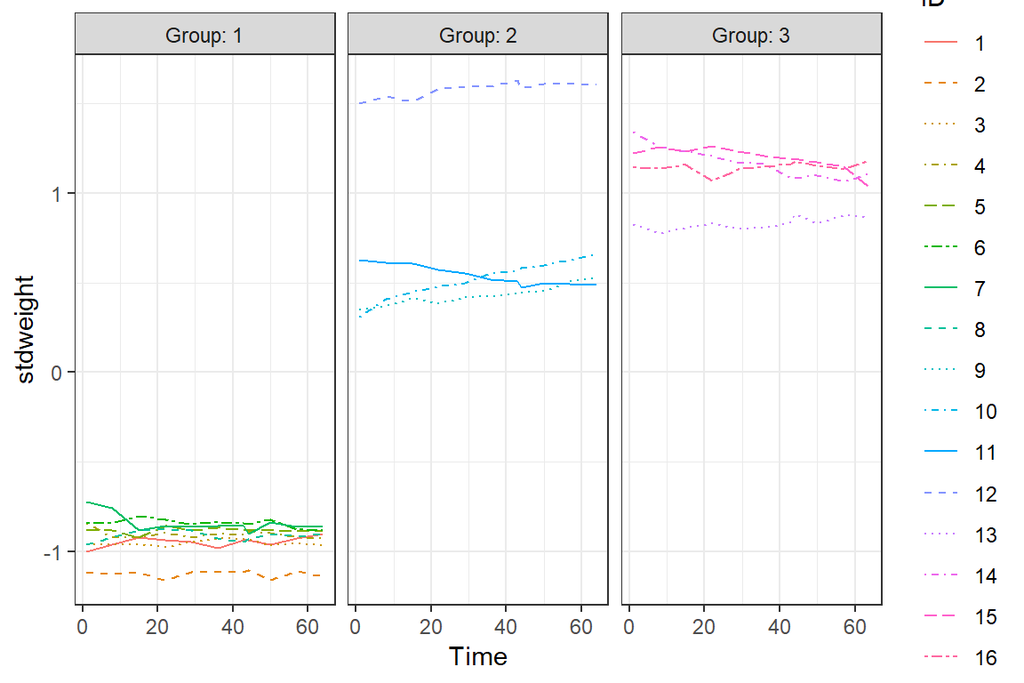

```r
RATSL <- RATSL %>%
  group_by(Time) %>%
  mutate(stdweight = (Weight - mean(Weight))/sd(Weight)) %>%
  ungroup()


ggplot(RATSL, aes(x = Time, y = stdweight, linetype = ID)) +
  geom_line() +
  scale_linetype_manual(values = rep(1:10, times=4)) +
  facet_grid(. ~ Group, labeller = label_both) +
  theme_bw() +geom_line(aes(color=ID))+
  scale_y_continuous(limits = c(min(RATSL$stdweight), max(RATSL$stdweight)))
```

Shows what we already knew.

Let’s now plot the mean effect of the 3 treatments in time.

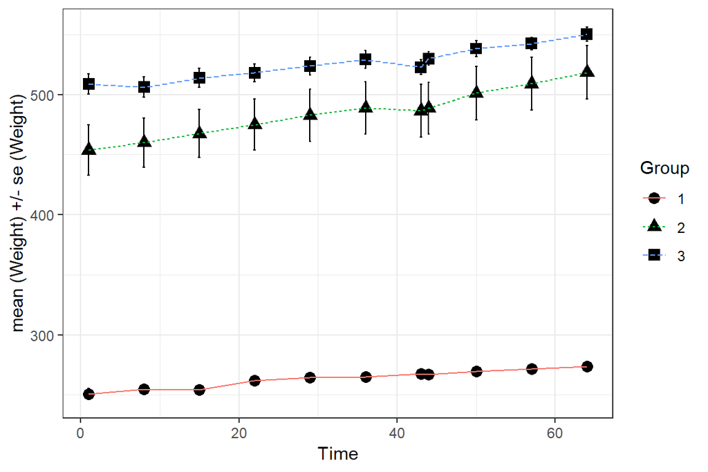

```r
n <- RATSL$Time %>% unique() %>% length()

# Summary data with mean and standard error of Weight by Group and Time
df <- RATSL %>%
  group_by(Group, Time) %>%
  summarise( mean = mean(Weight), se = sd(Weight)/sqrt(n)) %>%
  ungroup()


ggplot(df, aes(x = Time, y = mean, linetype = Group, shape = Group)) +
  geom_line() +
  geom_point(size=3) +
  geom_errorbar(aes(ymin=mean-se, ymax=mean+se, linetype="1"), width=0.3) +
  theme(legend.position = c(0.8,0.8)) + theme_bw() + geom_line(aes(color=Group))+
  scale_y_continuous(name = "mean (Weight) +/- se (Weight)")
```

Time for a quick and dirty analysis. Let’s average the all repeated observations taken from individual, so we “capture” the general effect of time in each individual.

```r
df1 <- RATSL %>%
    group_by(Group, ID) %>%
  summarise( mean=mean(Weight) ) %>%
  ungroup()
```

We can visualize the differences between groups directly.

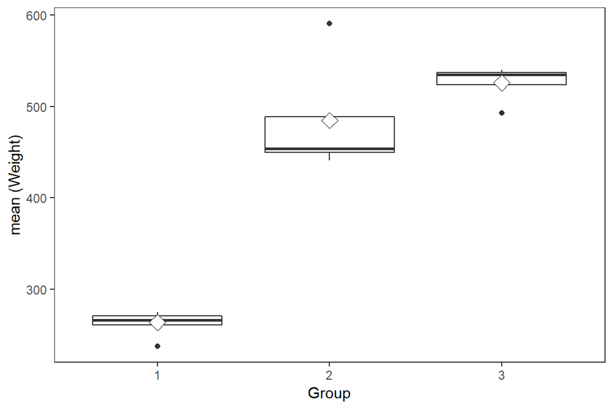

```r
ggplot(df1, aes(x = Group, y = mean))+
geom_boxplot()+
theme_bw() + theme(panel.grid.major = element_blank(), panel.grid.minor = element_blank())+
stat_summary(fun.y = "mean", geom = "point", shape=23, size=4, fill = "white")+
scale_y_continuous(name = "mean (Weight)")
```

Based on this graph, it looks like there’s an outlier in group 2. I wouldn’t remove it as there are too few variables (n=16). I think that the linear mixed model in this scenario would be able to take into account the specific variance between individuals.

Now we fit the linear model

```r
fitRATS <- lm(mean ~ Group, data = df1)
anova(fitRATS)
```

```
## Analysis of Variance Table
##
## Response: mean
##           Df Sum Sq Mean Sq F value    Pr(>F)
## Group      2 236732  118366  88.073 2.763e-08 ***
## Residuals 13  17471    1344
## ---
## Signif. codes:  0 '***' 0.001 '**' 0.01 '*' 0.05 '.' 0.1 ' ' 1
```

From the anova table we see that the group variable (reflecting treatments) significantly affects the weight of the rats.

```r
summary(fitRATS)
```

```
##
## Call:
## lm(formula = mean ~ Group, data = df1)
##
## Residuals:
##     Min      1Q  Median      3Q     Max
## -43.886 -27.031   2.284  10.588 105.750
##
## Coefficients:
##             Estimate Std. Error t value Pr(>|t|)
## (Intercept)   263.72      12.96  20.346 3.06e-11 ***
## Group2        220.99      22.45   9.844 2.16e-07 ***
## Group3        262.08      22.45  11.674 2.91e-08 ***
## ---
## Signif. codes:  0 '***' 0.001 '**' 0.01 '*' 0.05 '.' 0.1 ' ' 1
##
## Residual standard error: 36.66 on 13 degrees of freedom
## Multiple R-squared:  0.9313, Adjusted R-squared:  0.9207
## F-statistic: 88.07 on 2 and 13 DF,  p-value: 2.763e-08
```

From the summary table we see that treatment 3 (group 3) produces the highest weights, whereas treatment 1 (group 1) produces the lowest weights.

## Analysis of BPRS data

- According to chapter 9 from MABS

```r
setwd("D:/New folder/OneDrive for Business 1/Git/IODS/IODS-project/data")
BPRSL <- read.table(file = "BPRSL.txt",
                    header = TRUE,
                    dec = ".")
BPRSL$treatment <- factor(BPRSL$treatment)
BPRSL$subject <- factor(BPRSL$subject)
str(BPRSL)
```

```
## 'data.frame':    360 obs. of  5 variables:
##  $ treatment: Factor w/ 2 levels "1","2": 1 1 1 1 1 1 1 1 1 1 ...
##  $ subject  : Factor w/ 20 levels "1","2","3","4",..: 1 2 3 4 5 6 7 8 9 10 ...
##  $ weeks    : Factor w/ 9 levels "week0","week1",..: 1 1 1 1 1 1 1 1 1 1 ...
##  $ bprs     : int  42 58 54 55 72 48 71 30 41 57 ...
##  $ week     : int  0 0 0 0 0 0 0 0 0 0 ...
```

Let’s plot bprs versus the time, ignoring the fact that repeated measurements were done in each individual.

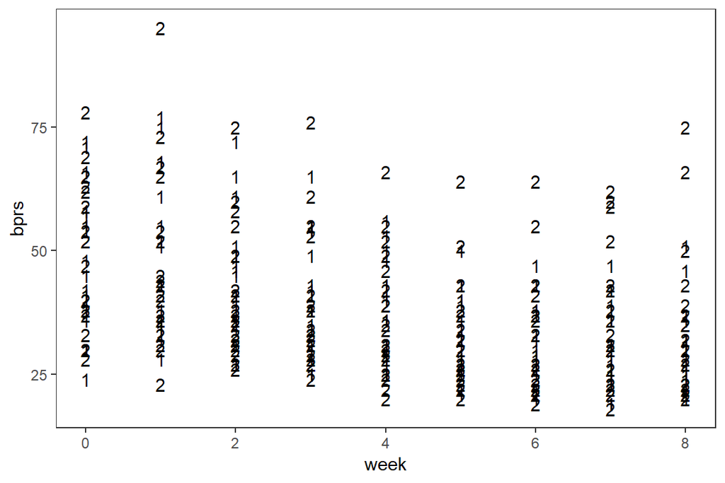

```r
ggplot(BPRSL, aes(x = week, y = bprs, group = subject))+
geom_text(aes(label = treatment))+
scale_y_continuous(name = "bprs")+
theme_bw()+
theme(panel.grid.major = element_blank(), panel.grid.minor = element_blank())
```

It doesn’t look like the treatments differ. To be sure, let’s run a quick linear model.

```r
fitBPRS <- lm(bprs ~ week + treatment, data = BPRSL)
anova(fitBPRS)
```

```
## Analysis of Variance Table
##
## Response: bprs
##            Df Sum Sq Mean Sq F value Pr(>F)
## week        1  12372 12371.5 80.9143 <2e-16 ***
## treatment   1     29    29.5  0.1927 0.6609
## Residuals 357  54584   152.9
## ---
## Signif. codes:  0 '***' 0.001 '**' 0.01 '*' 0.05 '.' 0.1 ' ' 1
```

No evidence was found to say the treatment had an effect on the bprs. However, the week significantly affected bprs.

```r
summary(fitBPRS)
```

```
##
## Call:
## lm(formula = bprs ~ week + treatment, data = BPRSL)
##
## Residuals:
##     Min      1Q  Median      3Q     Max
## -22.454  -8.965  -3.196   7.002  50.244
##
## Coefficients:
##             Estimate Std. Error t value Pr(>|t|)
## (Intercept)  46.4539     1.3670  33.982   <2e-16 ***
## week         -2.2704     0.2524  -8.995   <2e-16 ***
## treatment2    0.5722     1.3034   0.439    0.661
## ---
## Signif. codes:  0 '***' 0.001 '**' 0.01 '*' 0.05 '.' 0.1 ' ' 1
##
## Residual standard error: 12.37 on 357 degrees of freedom
## Multiple R-squared:  0.1851, Adjusted R-squared:  0.1806
## F-statistic: 40.55 on 2 and 357 DF,  p-value: < 2.2e-16
```

We can see the coefficients for the model. Treatment 2 had a positive effect on bprs, but non significant, whereas week had a negative significant effect.

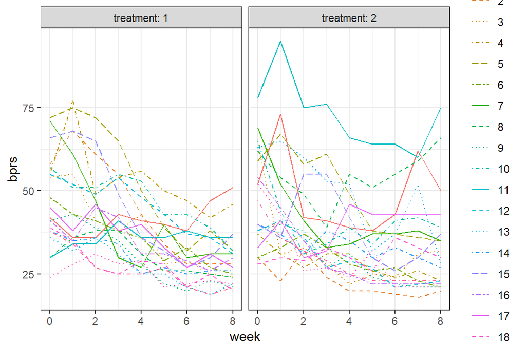

```r
ggplot(BPRSL, aes(x = week, y = bprs, linetype = subject)) +
  geom_line() +
  scale_linetype_manual(values = rep(1:10, times=4)) +
  facet_grid(. ~ treatment, labeller = label_both) +
  theme_bw() +geom_line(aes(color=subject))+
  scale_y_continuous(limits = c(min(BPRSL$bprs), max(BPRSL$bprs)))
```

From this graph we can see there’s a large variability between subjects, making it hard to differentiate treatment effects. But we can indeed see the effect of week.

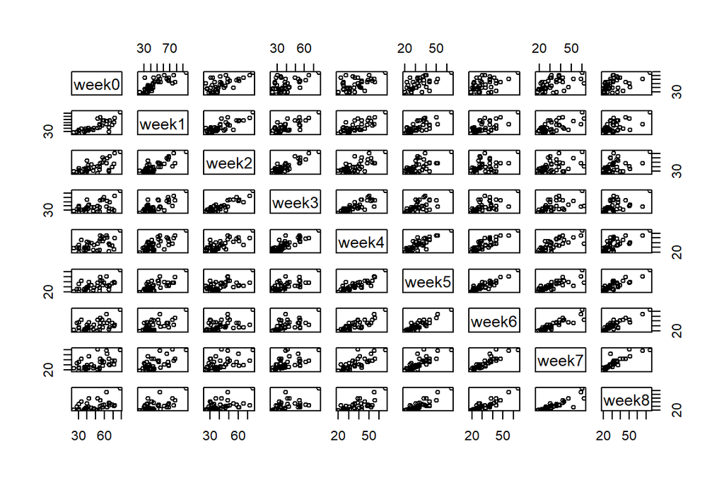

```r
BPRS<-read.table("https://raw.githubusercontent.com/KimmoVehkalahti/MABS/master/Examples/data/BPRS.txt",
                 header=T, sep=" ")
pairs(BPRS[, 3:11], cex = 0.7)
```

The weeks strongly correlate with each other.

Now we fit the linear mixed effect model with individuals as random intercepts, so the model accounts for the variability in subjects.

```r
mixedBPRS <- lmer(bprs ~ week + treatment + (1 | subject), data = BPRSL, REML = FALSE)
summary(mixedBPRS)
```

```
## Linear mixed model fit by maximum likelihood  ['lmerMod']
## Formula: bprs ~ week + treatment + (1 | subject)
##    Data: BPRSL
##
##      AIC      BIC   logLik deviance df.resid
##   2748.7   2768.1  -1369.4   2738.7      355
##
## Scaled residuals:
##     Min      1Q  Median      3Q     Max
## -3.0481 -0.6749 -0.1361  0.4813  3.4855
##
## Random effects:
##  Groups   Name        Variance Std.Dev.
##  subject  (Intercept)  47.41    6.885
##  Residual             104.21   10.208
## Number of obs: 360, groups:  subject, 20
##
## Fixed effects:
##             Estimate Std. Error t value
## (Intercept)  46.4539     1.9090  24.334
## week         -2.2704     0.2084 -10.896
## treatment2    0.5722     1.0761   0.532
##
## Correlation of Fixed Effects:
##            (Intr) week
## week       -0.437
## treatment2 -0.282  0.000
```

The fixed effects were the same found by the linear model, but the mixed model would allow for the intercept to be correct 20 times (one per individual). Ideally, the data should’ve been coded in a way that there would be 40 individuals. Now it thinks that each individual received both treatments, probably imposing some correlation between them. but I am no sure. The standard error is slightly smaller, so we can still try to improve the model by fitting a random intercept and model, so that the slope of each subject can also change according to week.

```r
mixedBPRS1 <- lmer(bprs ~ week + treatment + (week| subject), data = BPRSL, REML = FALSE)
summary(mixedBPRS1)
```

```
## Linear mixed model fit by maximum likelihood  ['lmerMod']
## Formula: bprs ~ week + treatment + (week | subject)
##    Data: BPRSL
##
##      AIC      BIC   logLik deviance df.resid
##   2745.4   2772.6  -1365.7   2731.4      353
##
## Scaled residuals:
##     Min      1Q  Median      3Q     Max
## -2.8919 -0.6194 -0.0691  0.5531  3.7976
##
## Random effects:
##  Groups   Name        Variance Std.Dev. Corr
##  subject  (Intercept) 64.8202  8.0511
##           week         0.9608  0.9802   -0.51
##  Residual             97.4307  9.8707
## Number of obs: 360, groups:  subject, 20
##
## Fixed effects:
##             Estimate Std. Error t value
## (Intercept)  46.4539     2.1052  22.066
## week         -2.2704     0.2977  -7.626
## treatment2    0.5722     1.0405   0.550
##
## Correlation of Fixed Effects:
##            (Intr) week
## week       -0.582
## treatment2 -0.247  0.000
```

Not so much difference. We can compare them by:

```r
anova(mixedBPRS,mixedBPRS1)
```

```
## Data: BPRSL
## Models:
## mixedBPRS: bprs ~ week + treatment + (1 | subject)
## mixedBPRS1: bprs ~ week + treatment + (week | subject)
##            Df    AIC    BIC  logLik deviance  Chisq Chi Df Pr(>Chisq)
## mixedBPRS   5 2748.7 2768.1 -1369.4   2738.7
## mixedBPRS1  7 2745.4 2772.6 -1365.7   2731.4 7.2721      2    0.02636 *
## ---
## Signif. codes:  0 '***' 0.001 '**' 0.01 '*' 0.05 '.' 0.1 ' ' 1
```

According to the likelihood ratio test, the random intercept and slope model is better (LRT=7.27, df=2,p=0.03).

At last, we fit a random intercept and slope model that allows for a treatment × week interaction, so the slope of week will change based on treatment.

```r
mixedBPRS2 <- lmer(bprs ~ week *treatment + (week| subject), data = BPRSL, REML = FALSE)
summary(mixedBPRS2)
```

```
## Linear mixed model fit by maximum likelihood  ['lmerMod']
## Formula: bprs ~ week * treatment + (week | subject)
##    Data: BPRSL
##
##      AIC      BIC   logLik deviance df.resid
##   2744.3   2775.4  -1364.1   2728.3      352
##
## Scaled residuals:
##     Min      1Q  Median      3Q     Max
## -3.0512 -0.6271 -0.0767  0.5288  3.9260
##
## Random effects:
##  Groups   Name        Variance Std.Dev. Corr
##  subject  (Intercept) 65.0016  8.0624
##           week         0.9688  0.9843   -0.51
##  Residual             96.4699  9.8219
## Number of obs: 360, groups:  subject, 20
##
## Fixed effects:
##                 Estimate Std. Error t value
## (Intercept)      47.8856     2.2522  21.262
## week             -2.6283     0.3589  -7.323
## treatment2       -2.2911     1.9090  -1.200
## week:treatment2   0.7158     0.4010   1.785
##
## Correlation of Fixed Effects:
##             (Intr) week   trtmn2
## week        -0.650
## treatment2  -0.424  0.469
## wek:trtmnt2  0.356 -0.559 -0.840
```

Next we check if the interaction is significant.

```r
drop1(mixedBPRS2, test="Chi")
```

```
## Single term deletions
##
## Model:
## bprs ~ week * treatment + (week | subject)
##                Df    AIC    LRT Pr(Chi)
## <none>            2744.3
## week:treatment  1 2745.4 3.1712 0.07495 .
## ---
## Signif. codes:  0 '***' 0.001 '**' 0.01 '*' 0.05 '.' 0.1 ' ' 1
```

The interaction was not significant for predicting pbrs (LRT=3.17,df=1,p=0.07).

Let’s see what the model predicts.

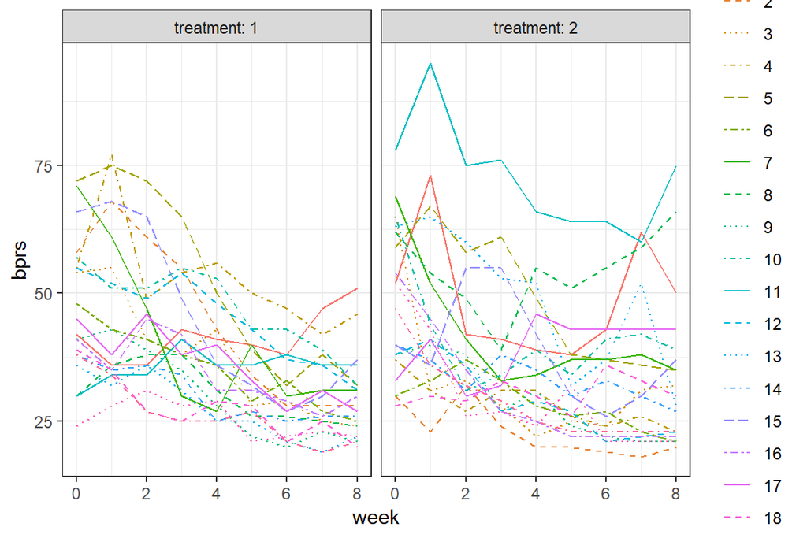

```r
Fitted <- fitted(mixedBPRS2)
BPRSL <- BPRSL %>% mutate(Fitted)

ggplot(BPRSL, aes(x = week, y = bprs, linetype = subject)) +
  geom_line() +
  scale_linetype_manual(values = rep(1:10, times=4)) +
  facet_grid(. ~ treatment, labeller = label_both) +
  theme_bw() +geom_line(aes(color=subject))
```

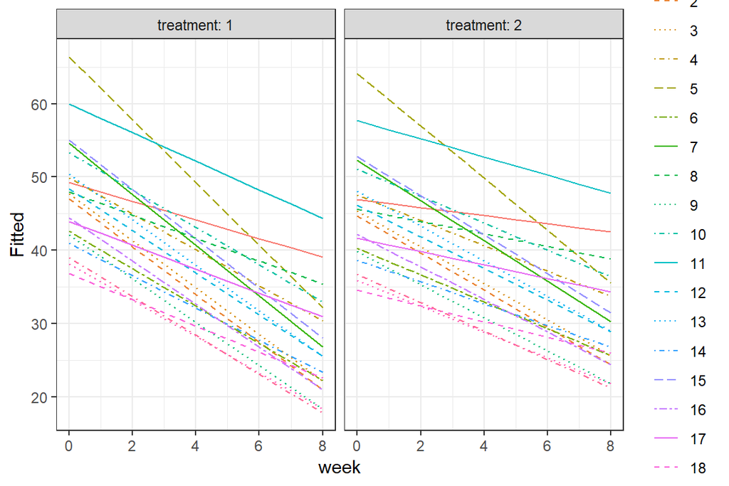

```r
ggplot(BPRSL, aes(x = week, y = Fitted, linetype = subject)) +
  geom_line() +
  scale_linetype_manual(values = rep(1:10, times=4)) +
  facet_grid(. ~ treatment, labeller = label_both) +
  theme_bw() +geom_line(aes(color=subject))
```

In the graph above we can see the negative effect of week on bprs, and that there’s not much difference between treatments. The fitted values include random effects, taking into account the variability within individuals across the weeks.